# MITx15.071x-U1-Assignment1.Rmd

Rahul Yadav

April 15, 2016

[figure not shown]

### An Analytical Detective

## Outline

#### Crime is an international concern, but it is documented and handled in very different ways in different countries. In the United States, violent crimes and property crimes are recorded by the Federal Bureau of Investigation (FBI). Additionally, each city documents crime, and some cities release data regarding crime rates. The city of Chicago, Illinois releases crime data from 2001 onward online.

#### Chicago is the third most populous city in the United States, with a population of over 2.7 million people. The city of Chicago is shown in the map below, with the state of Illinois highlighted in red.

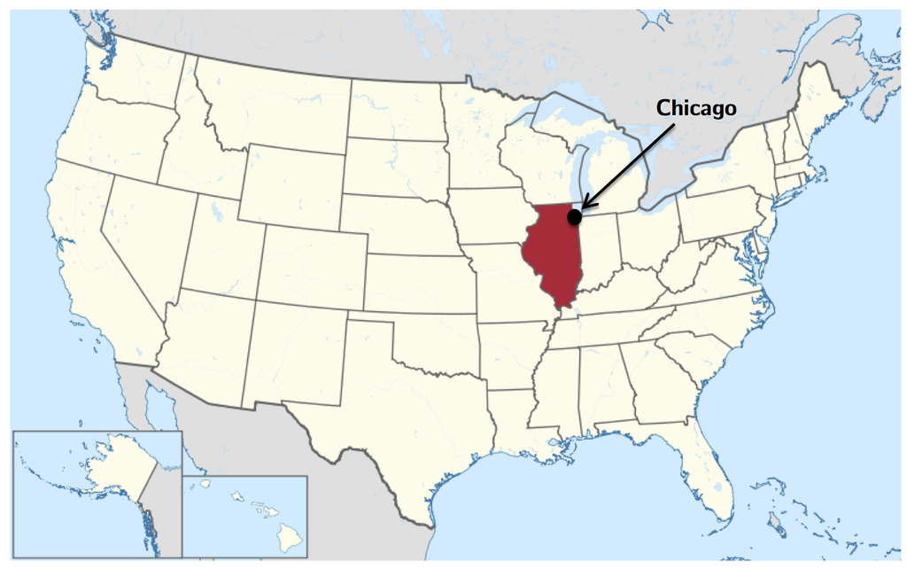

#### There are two types of crime:

#### Violent Crimes.

#### Property Crimes.

## Problem outline

#### In this problem, I’ll be focusing on one specific type of “property crime” called as “Grand Theft Auto” or GTA.

#### What is GTA?

*A GTA is an act of stealing, or attempting to steal, a car.*

#### In this Problem, I am gonna use some basic data analysis in R to understand the motor vechile thefts in Chicago.

## Fetching the dataset.

#### Our data set contains the following info as follows:

#### **ID:** a unique identifier for each observation

#### **Date:** the date the crime occurred

#### **LocationDescription:** the location where the crime occurred

#### **Arrest:** whether or not an arrest was made for the crime (TRUE if an arrest was made, and FALSE if an arrest was not made)

#### **Domestic:** whether or not the crime was a domestic crime, meaning that it was committed against a family member (TRUE if it was domestic, and FALSE if it was not domestic)

#### **Beat:** the area, or “beat” in which the crime occurred. This is the smallest regional division defined by the Chicago police department.

#### **District:** the police district in which the crime occured. Each district is composed of many beats, and are defined by the Chicago Police Department.

#### **CommunityArea:** the community area in which the crime occurred. Since the 1920s, Chicago has been divided into what are called “community areas”, of which there are now 77. The community areas were devised in an attempt to create socially homogeneous regions.

#### **Year:** the year in which the crime occurred.

#### **Latitude:** the latitude of the location at which the crime occurred.

#### **Longitude:** the longitude of the location at which the crime occurred.

#### **Let’s load our dataset.**

```r
mvt <- read.csv("C:/Users/pySag/Desktop/MITx15.071x/Datasets/mvtWeek1.csv")

#1.1 Let's view the structure of our dataset.
str(mvt)
```

```
## 'data.frame':    191641 obs. of  11 variables:
##  $ ID                 : int  8951354 8951141 8952745 8952223 8951608 8950793 8950760 8951611 8951802 8950706 ...
##  $ Date               : Factor w/ 131680 levels "1/1/01 0:01",..: 42824 42823 42823 42823 42822 42821 42820 42819 42817 42816 ...
##  $ LocationDescription: Factor w/ 78 levels "ABANDONED BUILDING",..: 72 72 62 72 72 72 72 72 72 72 ...
##  $ Arrest             : logi  FALSE FALSE FALSE FALSE FALSE TRUE ...
##  $ Domestic           : logi  FALSE FALSE FALSE FALSE FALSE FALSE ...
##  $ Beat               : int  623 1213 1622 724 211 2521 423 231 1021 1215 ...
##  $ District           : int  6 12 16 7 2 25 4 2 10 12 ...
##  $ CommunityArea      : int  69 24 11 67 35 19 48 40 29 24 ...
##  $ Year               : int  2012 2012 2012 2012 2012 2012 2012 2012 2012 2012 ...
##  $ Latitude           : num  41.8 41.9 42 41.8 41.8 ...
##  $ Longitude          : num  -87.6 -87.7 -87.8 -87.7 -87.6 ...
```

```r
#1.2 Let's also look at the statistical summary of our dataset.
summary(mvt)
```

```
##        ID                      Date
##  Min.   :1310022   5/16/08 0:00  :    11
##  1st Qu.:2832144   10/17/01 22:00:    10
##  Median :4762956   4/13/04 21:00 :    10
##  Mean   :4968629   9/17/05 22:00 :    10
##  3rd Qu.:7201878   10/12/01 22:00:     9
##  Max.   :9181151   10/13/01 22:00:     9
##                    (Other)       :191582
##                      LocationDescription   Arrest         Domestic
##  STREET                        :156564   Mode :logical   Mode :logical
##  PARKING LOT/GARAGE(NON.RESID.): 14852   FALSE:176105    FALSE:191226
##  OTHER                         :  4573   TRUE :15536     TRUE :415
##  ALLEY                         :  2308   NA's :0         NA's :0
##  GAS STATION                   :  2111
##  DRIVEWAY - RESIDENTIAL        :  1675
##  (Other)                       :  9558
##       Beat         District     CommunityArea        Year
##  Min.   : 111   Min.   : 1.00   Min.   : 0      Min.   :2001
##  1st Qu.: 722   1st Qu.: 6.00   1st Qu.:22      1st Qu.:2003
##  Median :1121   Median :10.00   Median :32      Median :2006
##  Mean   :1259   Mean   :11.82   Mean   :38      Mean   :2006
##  3rd Qu.:1733   3rd Qu.:17.00   3rd Qu.:60      3rd Qu.:2009
##  Max.   :2535   Max.   :31.00   Max.   :77      Max.   :2012
##                 NA's   :43056   NA's   :24616
##     Latitude       Longitude
##  Min.   :41.64   Min.   :-87.93
##  1st Qu.:41.77   1st Qu.:-87.72
##  Median :41.85   Median :-87.68
##  Mean   :41.84   Mean   :-87.68
##  3rd Qu.:41.92   3rd Qu.:-87.64
##  Max.   :42.02   Max.   :-87.52
##  NA's   :2276    NA's   :2276
```

```r
#1.3 What is the maximum value of the variable "ID"?
max( mvt $ ID )
```

```
## [1] 9181151
```

```r
#1.4 What is the min value of the variable "Beat"?
summary( mvt $ Beat)
```

```
##    Min. 1st Qu.  Median    Mean 3rd Qu.    Max.
##     111     722    1121    1259    1733    2535
```

```r
#1.5 How many observations have value TRUE in the '"Arrest" variale?
summary( mvt $ Arrest )
```

```
##    Mode   FALSE    TRUE    NA's
## logical  176105   15536       0
```

```r
#1.6 How many observations have a "LocationDescription" value of "Alley"?
summary( mvt $ LocationDescription == "ALLEY")
```

```
##    Mode   FALSE    TRUE    NA's
## logical  189333    2308       0
```

## Understanding Dates in R

#### In many datasets, like this one, you have a date field. Unfortunately, R does not automatically recognize entries that look like dates. We need to use a function in R to extract the date and time. Take a look at the first entry of Date (remember to use square brackets when looking at a certain entry of a variable).

```r
#2.1 Whats the format of variable "DATE"
# if we look at the summary of the dataset, it's in MM/DD/YY hr:min format.

#2.2 What is the "month" & "year" of the median date in our dataset?

  # To do this, 1st we have to convert "char" data type into a "Date" object in R.
  # Then using our summary() view the median date in our dataset

# [Syntax] : as.Date( strptime( R object, format, .. ))

DateConvert <- as.Date(strptime(mvt$Date, "%m/%d/%y %H:%M"))

summary(DateConvert)
```

```
##         Min.      1st Qu.       Median         Mean      3rd Qu.
## "2001-01-01" "2003-07-10" "2006-05-21" "2006-08-23" "2009-10-24"
##         Max.
## "2012-12-31"
```

```r
#2.3 In which "month"" did the fewest motor vehicle thefts occur?

# To do the following, we take a three step approach:
    #a. Extracting month
    #b. Extracting day
    #c. Replacing our old Date variable to DataConvert.

mvt $ Month <- months(DateConvert)
mvt $ Weekday <- weekdays(DateConvert)
mvt $ Date <- DateConvert

# Now using our table command, we are going to answer our question.
which.min( table( mvt $ Month ) )
```

```
## February
##        4
```

```r
mvt $ Month[4]
```

```
## [1] "December"
```

```r
#2.4 On which weekday did the most motor vehicle thefts occur?
which.max( table( mvt $ Weekday) )
```

```
## Friday
##      1
```

```r
mvt $ Weekday[1]
```

```
## [1] "Monday"
```

```r
#2.5 Which month has the largest numbre of motor vehicle thefts for which an arrest was made?
which.max( table( mvt $ Arrest, mvt $ Arrest) )
```

```
## [1] 1
```

```r
mvt $ Month[11]
```

```
## [1] "December"
```

```r
arrest <- subset(mvt, mvt$Arrest==T)
which.max(table(arrest$Month))
```

```
## January
##       5
```

## Visulizing Crime Trends

#### **Histogram**

#### Let’s make some plots to understand how crime has changed over time in Chicago.

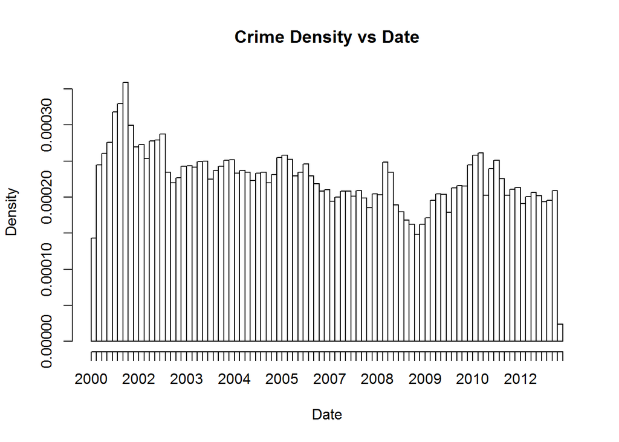

```r
hist( mvt$Date, breaks = 100, xlab = "Date", main = "Crime Density vs Date")
```

```r
# Looking at the plot, answert the following questions, in general:
  #1. Does the crime increases or decreases from 2002-12?
  #2. Does the crime increases or decreases from 2005-08?
  #3. Does the crime increases or decreases from 2009-11?
```

#### **Observation:** Looking at the histogram we can fairly say the following:

#### Crime decreases.

#### Crime decreases.

#### Crime increases.

#### **Boxplot**

#### Using a Boxplot, we try to answer the following:

#### Create a boxplot of the variable “Date”, sorted by the variable “Arrest”.

#### Does it look like there were more crimes for which arrests were made in the first half of the time period or the second half of the time period? (Note that the time period is from 2001 to 2012, so the middle of the time period is the beginning of 2007.)

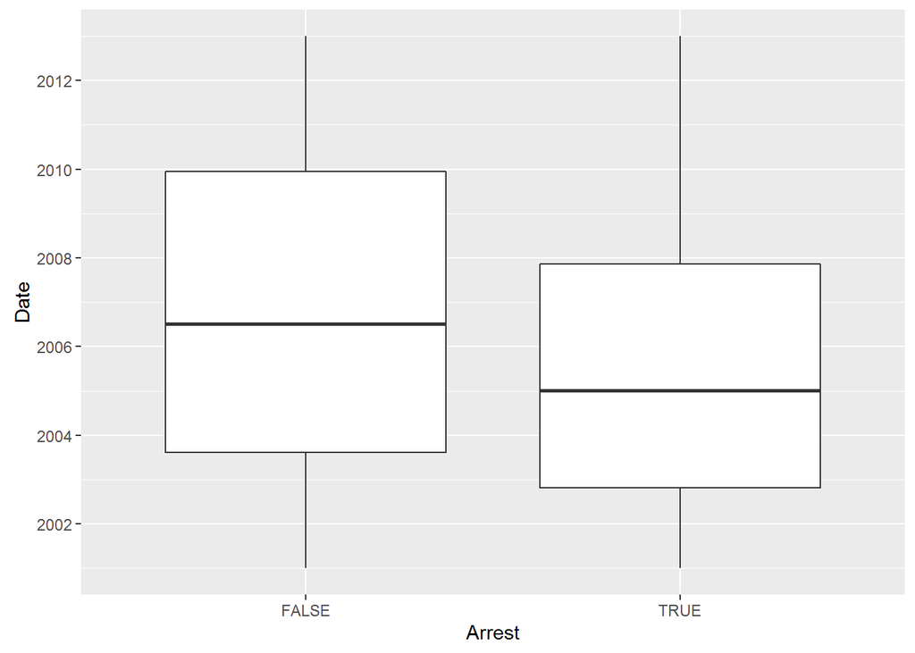

```r
library(ggplot2)

ggplot(mvt, aes(x=Arrest, y=Date)) + geom_boxplot()
```

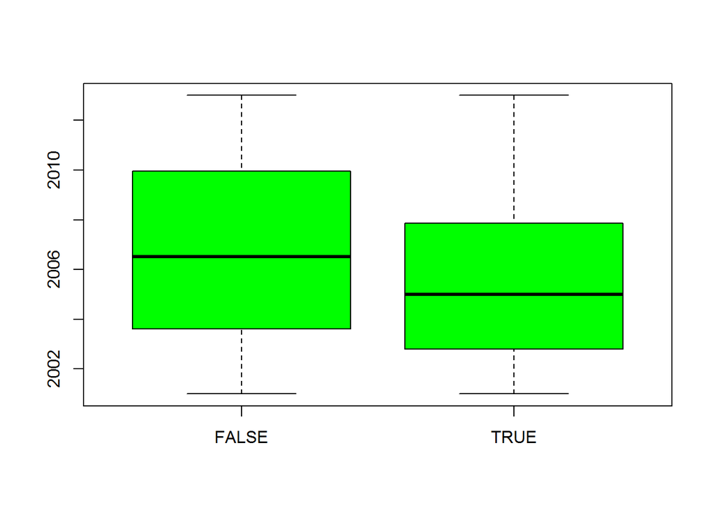

```r
# Here's another way of doing this:
  # boxplot( formula,data, color, x-axis <- label, y-axis <- label)
  # Since we are asked to sort(group) Date with Arrest, this is our formula.
  # data is your data frame i.e "mvt"

boxplot( Date ~ Arrest, data <- mvt, xlab <- "Arrest", ylab <- "Date", main <- "Box plot of Arrest Dates", col = "green")
```

#### Let’s investigate in further1

#### **[ Question ]** : For what proportions of GTA iFilter was an arrest made?

```r
tapply(mvt$Arrest,mvt$Year, mean)
```

```
##       2001       2002       2003       2004       2005       2006
## 0.10411728 0.11278195 0.10794261 0.10040327 0.09269595 0.08087961
##       2007       2008       2009       2010       2011       2012
## 0.08487395 0.07061267 0.06903920 0.04523456 0.03996930 0.03902924
```

```r
# for 2001
# for 2007
# for 2012
```

## Location of Heat

#### Now we want to help chicago pd to mark locations where most theft has occured. By doing this we can provide decisions that will help Chicago pd to improvise there crime control measures.

#### Problem: Find top five locations where motor vehicle theft occured.

#### While we can simply throw in a summary function to get the statistical information, this could make the whole interpretation a bit messy. Fortunatly, R provide us with another function called as “sort()”

#### Let’s take it for a spin!

```r
#4.1 Which locations are the top five locations for motor vechile theft, excluding the "other category".

sort(table(mvt $ LocationDescription))
```

```
##
##     AIRPORT BUILDING NON-TERMINAL - SECURE AREA
##                                               1
##                  AIRPORT EXTERIOR - SECURE AREA
##                                               1
##                                 ANIMAL HOSPITAL
##                                               1
##                                 APPLIANCE STORE
##                                               1
##                                       CTA TRAIN
##                                               1
##                         JAIL / LOCK-UP FACILITY
##                                               1
##                                       NEWSSTAND
##                                               1
##                                          BRIDGE
##                                               2
##               COLLEGE/UNIVERSITY RESIDENCE HALL
##                                               2
##                               CURRENCY EXCHANGE
##                                               2
##                                   BOWLING ALLEY
##                                               3
##                                  CLEANING STORE
##                                               3
##                           MEDICAL/DENTAL OFFICE
##                                               3
##                              ABANDONED BUILDING
##                                               4
## AIRPORT BUILDING NON-TERMINAL - NON-SECURE AREA
##                                               4
##                                      BARBERSHOP
##                                               4
##                  LAKEFRONT/WATERFRONT/RIVERBANK
##                                               4
##                                         LIBRARY
##                                               4
##                                SAVINGS AND LOAN
##                                               4
##  AIRPORT TERMINAL UPPER LEVEL - NON-SECURE AREA
```

[output cut: 102 more lines]

```
##                                            1302
##                   RESIDENTIAL YARD (FRONT/BACK)
##                                            1536
##                          DRIVEWAY - RESIDENTIAL
##                                            1675
##                                     GAS STATION
##                                            2111
##                                           ALLEY
##                                            2308
##                                           OTHER
##                                            4573
##                  PARKING LOT/GARAGE(NON.RESID.)
##                                           14852
##                                          STREET
##                                          156564
```

#### Now let’s find top 5 locations of theft:

#### We are going to use R “subset()” function.

```r
#Problem 4.2
lds <- mvt $ LocationDescription

Top5 <- subset( mvt, lds == "GAS STATION" | lds == "ALLEY" | lds == "STREET" | lds == "PARKING LOT/GARAGE(NON.RESID.)" | lds == "DRIVEWAY - RESIDENTIAL", na.rm = TRUE)

Top5 $ LocationDescription <- factor( Top5 $ LocationDescription )
nrow( Top5 )
```

```
## [1] 177510
```

#### **Note**:

#### R will remember the other categories of the LocationDescription variable from the original dataset.

#### So running table(Top5$LocationDescription) will have a lot of unnecessary output.

#### To make our tables a bit nicer to read, we can refresh this variable by using factor().

```r
#Problem 4.3
# Use str to view top location where the arrest were made.
table( Top5 $ Arrest, Top5 $ LocationDescription)
```

```
##
##          ALLEY DRIVEWAY - RESIDENTIAL GAS STATION
##   FALSE   2059                   1543        1672
##   TRUE     249                    132         439
##
##         PARKING LOT/GARAGE(NON.RESID.) STREET
##   FALSE                          13249 144969
##   TRUE                            1603  11595
```

```r
#                     or
tapply(Top5 $ Arrest, Top5 $ LocationDescription, mean)
```

```
##                          ALLEY         DRIVEWAY - RESIDENTIAL
##                     0.10788562                     0.07880597
##                    GAS STATION PARKING LOT/GARAGE(NON.RESID.)
##                     0.20795831                     0.10793159
##                         STREET
##                     0.07405917
```

```r
# if we look at the mean of all top 5 loactions,
  # Location with highest mean --->  "Gas Station"

#4.4 On which day of the week most of the arrest at gas station were made.
day <- subset( Top5, Top5 $ LocationDescription == "GAS STATION")
which.max(table(day $ Weekday))
```

```
## Saturday
##        3
```

```r
day $ Weekday[3]
```

```
## [1] "Thursday"
```

#### **Note**:

#### Don’t get into the trap of the followed output : 3.

#### Always use the first output.

### Stock Dynamics

## Outline

#### A stock market is where buyers and sellers trade shares of a company, and is one of the most popular ways for individuals and companies to invest money. The size of the world stock market is now estimated to be in the trillions. The largest stock market in the world is the New York Stock Exchange (NYSE), located in New York City. About 2,800 companies are listed on the NSYE. In this problem, we’ll look at the monthly stock prices of five of these companies: IBM, General Electric (GE), Procter and Gamble, Coca Cola, and Boeing. The data used in this problem comes from Infochimps.

[figure not shown]

#### We will be analysis the monthly stock prices of five of the following companies:

#### **IBM**.

#### **GE( Genereal Electrics )**

#### **P&G( Proctor & Gamble )**

#### **CocaCola**

#### **Boeing**

#### **Preliminaries**

#### Let’s load our data sets, and call the data frames respectively as:

#### “IBM”

#### “GE”

#### “ProcterGamble”

#### “CocaCola”

#### “Boeing”

#### Each data frame has “two” variables (rows), described as follows:

#### **Date** : the date of the stock price, always given as the first of the month.

#### **StockPrice** : the average stock price of the company in the given month.

#### In this problem, we’ll take a look at how the stock dynamics of these companies have changed over time.

```r
# Objective:
  # Loading the datasets.
  # Creating desires data frames.
getwd()
```

```
## [1] "C:/Users/pySag/Desktop/MITx15.071x"
```

```r
IBM <- read.csv("C:/Users/pySag/Desktop/MITx15.071x/Datasets/IBMStock.csv")
GE <- read.csv("C:/Users/pySag/Desktop/MITx15.071x/Datasets/GEStock.csv")
ProcterGamble <- read.csv("C:/Users/pySag/Desktop/MITx15.071x/Datasets/ProcterGambleStock.csv")
CocaCola <- read.csv("C:/Users/pySag/Desktop/MITx15.071x/Datasets/CocaColaStock.csv")
Boeing <- read.csv("C:/Users/pySag/Desktop/MITx15.071x/Datasets/BoeingStock.csv")
```

## **Problem 1** - **Summary Statistics**

#### Before working with these data sets, we need to convert the dates into a format that R can understand.

#### Take a look at the structure of one of the datasets using the str function.

```r
str(IBM)
```

```
## 'data.frame':    480 obs. of  2 variables:
##  $ Date      : Factor w/ 480 levels "1/1/00","1/1/01",..: 11 171 211 251 291 331 371 411 451 51 ...
##  $ StockPrice: num  360 347 327 320 270 ...
```

#### At present the “Date” variable is stored as a “factor”.

#### Although R can detect Date as factor, it can’t use that variable.

#### Hence, we will convert it into a suitable format that R can understand.

#### We will make use of R date format converted function called “as.Date()”.

#### It take an Object( in this case, a data frame ) & a fomat as it’s argument.

```r
# To our data frame <- as.Date( object to be formated, "format" )

IBM $ Date <- as.Date(IBM $ Date, "%m/%d/%y")

GE $ Date <- as.Date(GE $ Date, "%m/%d/%y")

CocaCola $ Date <- as.Date(CocaCola $ Date, "%m/%d/%y")

ProcterGamble $ Date <- as.Date(ProcterGamble $ Date, "%m/%d/%y")

Boeing $ Date = as.Date(Boeing $ Date, "%m/%d/%y")

#(Question 1): How many obv. are there in each data set?
str( IBM )
```

```
## 'data.frame':    480 obs. of  2 variables:
##  $ Date      : Date, format: "1970-01-01" "1970-02-01" ...
##  $ StockPrice: num  360 347 327 320 270 ...
```

```r
str( GE )
```

```
## 'data.frame':    480 obs. of  2 variables:
##  $ Date      : Date, format: "1970-01-01" "1970-02-01" ...
##  $ StockPrice: num  74.3 70 72.2 74.3 66.7 ...
```

```r
str( CocaCola )
```

```
## 'data.frame':    480 obs. of  2 variables:
##  $ Date      : Date, format: "1970-01-01" "1970-02-01" ...
##  $ StockPrice: num  83.4 81.6 81.3 76.8 69.3 ...
```

```r
str( ProcterGamble )
```

```
## 'data.frame':    480 obs. of  2 variables:
##  $ Date      : Date, format: "1970-01-01" "1970-02-01" ...
##  $ StockPrice: num  111.9 111.5 108.5 106.3 73.3 ...
```

```r
str( Boeing )
```

```
## 'data.frame':    480 obs. of  2 variables:
##  $ Date      : Date, format: "1970-01-01" "1970-02-01" ...
##  $ StockPrice: num  27.9 22.4 23.1 21.6 18.9 ...
```

```r
# (1.2): What is the earliest year in our datasets?
# (1.3) The last observations in our datasets will the latest years
which.max( IBM $ Date )
```

```
## [1] 480
```

```r
IBM $ Date[480]
```

```
## [1] "2009-12-01"
```

```r
GE $ Date[480]
```

```
## [1] "2009-12-01"
```

```r
CocaCola $ Date[480]
```

```
## [1] "2009-12-01"
```

```r
ProcterGamble $ Date[480]
```

```
## [1] "2009-12-01"
```

```r
Boeing $ Date[480]
```

```
## [1] "2009-12-01"
```

```r
# (1.4) What is the "Mean Stock Price" for IBM over these years?
mean( IBM $ StockPrice )
```

```
## [1] 144.375
```

```r
# (1.5) Which is the "Minimum Stock Price" for GE over these years?
min( GE $ StockPrice )
```

```
## [1] 9.293636
```

```r
# (1.6) What is the "Maximum Stock Price" for Coca Cola over these years?
max( CocaCola $ StockPrice )
```

```
## [1] 146.5843
```

```r
# (1.7) What is the "Median Stock Price" for Boeing over these years?
median( Boeing $ StockPrice )
```

```
## [1] 44.8834
```

```r
# (1.8) What is the "Standard Deviation of the Stock Price" for P&G over these years?
sd( ProcterGamble $ StockPrice )
```

```
## [1] 18.19414
```

## **Problem 1** **Visulaizing Stock Dynamics**

#### Now let’s visualize “Stock Trends” in “Stock Prices” over these period. Following are the steps we need to take:

#### Use Plot function of R.

#### Plot “Date” on x axis & “stock Price” on y-axis.

#### Rather then histogram, we are using a line, just add-inn the argument “type =”l“.

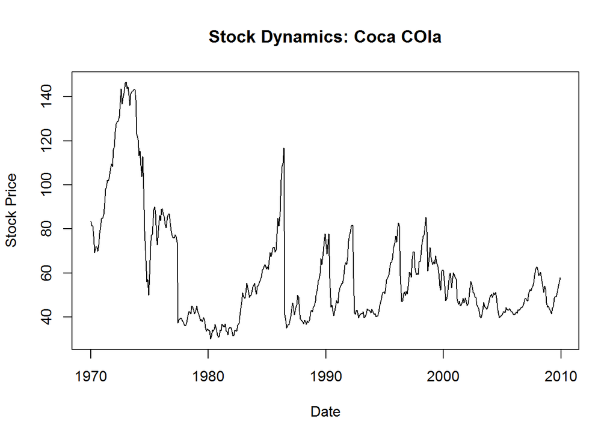

```r
# (2.1) Visualize the CocCoala StockPrice vs Date using "line graph"
plot( x <- CocaCola $ Date, y <- CocaCola $ StockPrice, type = "l", xlab = "Date", ylab = "Stock Price" )
title( main <- "Stock Dynamics: Coca COla")
```

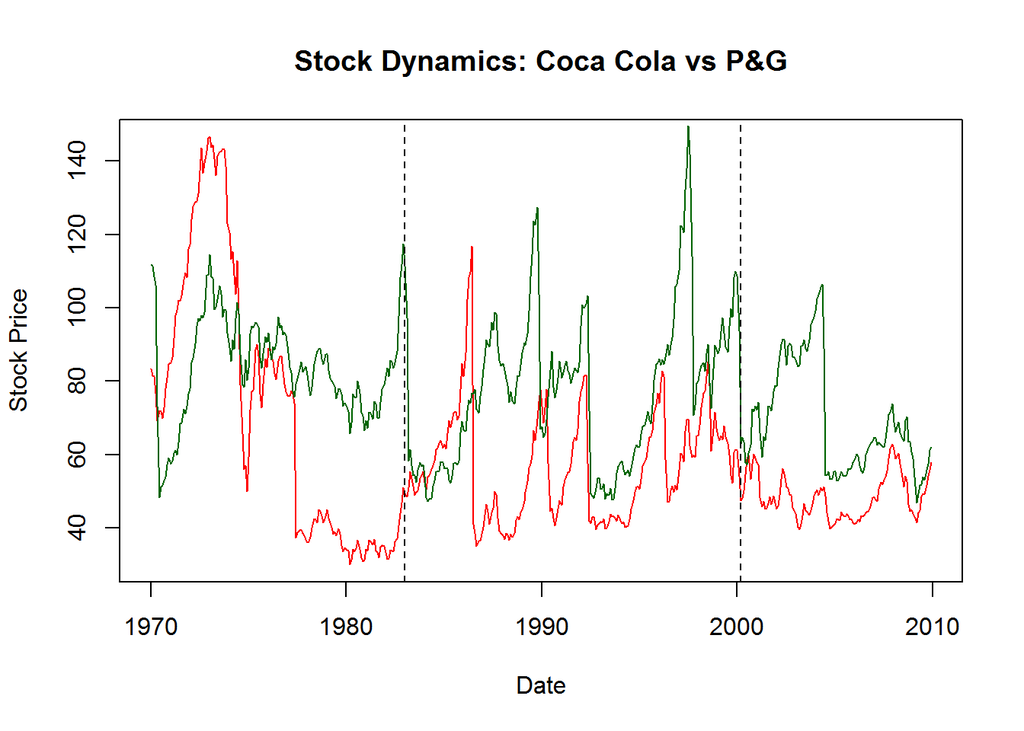

```r
# Around what year did Coca-Cola has its "highest" stock price in this time period?
        # 1973
# Around what year did Coca-Cola has its "lowest" stock price in this time period?
        # 1980

# (2.2) Visualize P&G aswell.
plot( CocaCola $ Date, CocaCola $ StockPrice, type = "l", col ="red", xlab = "Date", ylab = "Stock Price")

# lets overlap the two:
lines( ProcterGamble $ Date, ProcterGamble $ StockPrice, col = "dark green")

# Lets add some titile
title( main <- "Stock Dynamics: Coca Cola vs P&G")

# (2.3) In March 2000, stock market crashed due to tach.bubble burst, acc. to plot which companies stocks plunged down?

# To answer this, we will add a line separation
abline( v = as.Date( c( "2000-03-01", "1983-01-01")), lty=2)
```

## **Problem 3** : **Visualizing Stock Dynamics form 1995 - 2005**

#### To do the following, these steps are listed below:

#### Plot the Coca Cola stock prices using obv. numbered from 301 to 432.

#### Make the y-axis range from 0 to 210.

#### Add the rest of the companies

#### Discriminate them accordingly using colors.

[figure not shown]

```r
# (3.1)
plot(CocaCola$Date[301:432], CocaCola$StockPrice[301:432], type="l", col="red", ylim=c(0,210),lwd=2, xlab="Date", ylab="Stock Price")

# Let's add the other four.
lines(IBM$Date[301:432], IBM$StockPrice[301:432], type="l", col="blue", lwd=2, lty=5)
lines(Boeing$Date[301:432], Boeing$StockPrice[301:432], type="l", col="green",lwd=2, lty=2)
lines(ProcterGamble$Date[301:432], ProcterGamble$StockPrice[301:432], type="l", col="purple", lwd=2,lty=3)
lines(GE$Date[301:432], GE$StockPrice[301:432], type="l", col="orange",lwd=2, lty=4)

# Let's give it some title
title( main = "Stock Dynamics Discrimination, year 1995-2010")

#(3.2) Which stock fell the most right after the technology bubble burst in March 2000?
abline(v=as.Date(c("2000-01-01")), lwd=2, lty=2)

# (3.3) Which stock reaches the highest value in the time period 1995-2005?
abline(v=as.Date(c("1995-01-01","2005-01-01")), lty=1, col="brown")

# (3.4) In October of 1997, there was a global stock market crash that was caused by an economic crisis in Asia. Comparing September 1997 to November 1997, which companies saw a decreasing trend in their stock price?
abline(v=as.Date(c("1997-09-01","1997-11-01")), lty=2, col="cyan")
```

– –

## Problem 4 Monthly Trends

#### Lastly, let’s see if stocks tend to be higher or lower during certain months. Thus the question is as follows, Calculate the mean stock price of IBM, sorted my months. To do the following, steps are discussed down below:

#### We will be using tpply()

#### To sort the months, use months( IBM $ Date ).

let’s take it for a spin!

```r
#(4.1) Comapre monthly average stock price of IBM to overall average stock price.

# Here our monthly average stock prices for IBM.
tapply(IBM $ StockPrice,months( IBM $ Date ), mean)
```

```
##     April    August  December  February   January      July      June
##  152.1168  140.1455  140.7593  152.6940  150.2384  139.0670  139.0907
##     March       May  November   October September
##  152.4327  151.5022  138.0187  137.3466  139.0885
```

```r
# Here's our overall montly average stock prices for IBM.
sort( tapply(IBM $ StockPrice, IBM $ Date, mean ), decreasing = TRUE )
```

```
## 1973-02-01 1973-03-01 1973-01-01 1973-04-01 1972-08-01 1972-09-01
##  438.90158  437.40409  424.50619  423.72500  413.71739  400.13750
## 1972-07-01 1972-12-01 1972-06-01 1973-05-01 1972-05-01 1972-04-01
##  396.01250  395.76316  394.84682  393.87545  389.92045  389.02500
## 1972-10-01 1972-11-01 1972-03-01 1972-02-01 1970-01-01 1971-04-01
##  388.62500  384.23800  378.08000  369.93150  360.31905  357.05381
## 1971-03-01 1972-01-01 1970-02-01 1971-05-01 1971-02-01 1970-03-01
##  351.90783  350.69048  346.72368  343.32500  333.86895  327.34571
## 1971-12-01 1970-04-01 1971-06-01 1973-06-01 1971-01-01 1970-12-01
##  327.18182  319.85273  319.02909  317.53000  316.45050  314.53409
## 1979-04-01 1973-07-01 1979-03-01 1979-05-01 1979-01-01 1971-10-01
##  313.61350  312.34524  309.67773  309.33636  308.82500  305.40524
## 1979-02-01 1971-07-01 1971-09-01 1973-08-01 1971-08-01 1971-11-01
##  304.75789  304.65476  304.24429  303.84783  302.39773  296.87524
## 1970-11-01 1970-10-01 1978-08-01 1978-09-01 1978-12-01 1976-09-01
##  296.42550  294.46636  291.15304  290.28200  281.50200  281.00143
## 1977-03-01 1973-09-01 1978-10-01 1973-11-01 1976-07-01 1970-09-01
##  280.86000  278.48737  278.42682  277.20857  274.90524  274.85762
## 1976-08-01 1973-10-01 1977-02-01 1977-01-01 1976-12-01 1970-05-01
##  274.75727  274.50565  272.37526  272.36905  271.79591  270.37524
## 1977-04-01 1976-10-01 1977-08-01 1970-06-01 1976-11-01 1978-01-01
##  270.15050  269.93524  268.02870  267.20500  267.15050  267.11476
## 1977-07-01 1978-07-01 1977-12-01 1978-11-01 1978-06-01 1978-05-01
##  266.63316  265.37600  265.25714  265.12000  265.01273  263.25136
## 1976-06-01 1977-09-01 1976-04-01 1976-03-01 1977-11-01 1978-02-01
##  262.76773  261.95381  261.88810  259.70739  258.55524  258.21789
## 1977-10-01 1976-02-01 1977-06-01 1977-05-01 1976-05-01 1970-07-01
##  258.16238  257.95421  256.47955  253.55476  252.93150  252.59682
## 1973-12-01 1978-04-01 1970-08-01 1974-03-01 1978-03-01 1974-01-01
##  252.00650  247.67650  247.35762  244.17286  242.54727  241.10818
## 1976-01-01 1974-02-01 1974-04-01 1974-05-01 1974-06-01 1975-11-01
##  241.00143  234.92789  231.04238  221.70545  220.01900  219.62000
## 1975-12-01 1975-05-01 1999-05-01 1975-03-01 1975-06-01 1974-07-01
##  219.28636  214.70381  213.96350  213.93200  211.12619  210.93773
## 1975-02-01 1975-04-01 1975-10-01 1975-07-01 1974-08-01 1999-04-01
##  206.47474  206.35864  205.93043  201.60364  199.62545  187.62286
## 1999-01-01 1975-09-01 1975-08-01 1974-11-01 1974-10-01 1999-03-01
##  186.34263  184.56619  182.29238  181.57000  175.57696  175.42000
## 1999-02-01 1998-12-01 1974-09-01 1974-12-01 1975-01-01 1987-08-01
##  173.20789  172.43318  169.39400  168.42333  168.15455  168.12095
```

[output cut: 105 more lines]

```
##   65.49150   65.42304   65.23500   65.15652   64.60667   63.49350
## 1980-07-01 1982-04-01 1981-03-01 1981-02-01 1979-11-01 1982-02-01
##   63.35682   63.35048   63.06409   62.94789   62.82286   62.04158
## 1994-06-01 1981-04-01 1982-06-01 1982-01-01 1994-05-01 1980-03-01
##   62.03636   60.68095   60.02636   59.85900   59.66333   59.28333
## 1982-03-01 1981-06-01 1994-07-01 1992-12-01 1980-06-01 1994-01-01
##   59.14957   58.74136   58.62000   58.20091   58.13381   57.90143
## 1981-05-01 1981-08-01 1993-12-01 1981-07-01 1994-03-01 1981-12-01
##   57.05350   56.95476   56.42227   56.15682   55.25783   54.95682
## 1981-09-01 1994-04-01 1994-02-01 1993-03-01 1980-05-01 1980-04-01
##   54.67524   54.60105   54.14105   54.08957   53.87810   53.65667
## 1981-10-01 1981-11-01 1993-02-01 1993-11-01 1993-06-01 1993-04-01
##   52.74091   51.82700   51.71842   51.60810   51.23500   50.10952
## 1993-05-01 1993-01-01 1993-07-01 1993-10-01 1993-09-01 1993-08-01
##   49.18400   48.92000   45.91381   44.25238   43.57286   43.39500
```

```r
sort(tapply(GE$StockPrice, months(GE$Date), mean), decreasing = TRUE)
```

```
##     April     March  February   January       May  December  November
##  64.48009  63.15055  62.52080  62.04511  60.87135  59.10217  57.28879
##      July    August      June September   October
##  56.73349  56.50315  56.46844  56.23913  56.23897
```

```r
sort(tapply(CocaCola$StockPrice, months(CocaCola$Date), mean), decreasing = TRUE)
```

```
##     April     March       May      June  February   January  December
##  62.68888  62.07135  61.44358  60.81208  60.73475  60.36849  59.73223
##  November      July    August   October September
##  59.10268  58.98346  58.88014  57.93887  57.60024
```

```r
#(4.3) In whic month are the stock prices lower?
which.min( tapply(GE $ StockPrice, months(GE $ Date), mean))
```

```
## October
##      11
```

### Demographics and Employment in US

## Outline

We are going to analyse “employment Statistics”, this was discovered in the wake of great recession in 2009. It is used to gauge the overall strength of the economy. In US, the govt measures unemployment using the “Current Population Survey(CPS)”.

CPS collects demographic and employment information from a wide range of US citizens. each month.

## Objective

#### In this assignment we will use the former techniques of doing data basic summary stats aswell as some new one on a relativly fresh data set of Sept 2013.[dataset](http://thedataweb.rm.census.gov/ftp/cps_ftp.html)

#### The Observations in the datssets represent people surveyed in the Sept 2013 CPS. While the full dataset has 385 variables, in this exercise we will use relativly compact version of dataset which has the following varibles:

#### * **PeopleInHOusehold**: The number of people in the interviewee’s household.

#### * **Region**: The census region where the interviewee lives.

#### * **State**: State: The state where the interviewee lives.

#### * **MetroAreaCode**: A code that identifies the metropolitan area in which the interviewee lives (missing if the interviewee does not live in a metropolitan area). The mapping from codes to names of metropolitan areas is provided in the file.

#### * **Age**: The age, in years, of the interviewee. 80 represents people aged 80-84, and 85 represents people aged 85 and higher.

#### * **Married**: The marriage status of the interviewee.

#### * **Sex**: The sex of the interviewee.The maximum level of education obtained by the interviewee.

#### * **Education**: The maximum level of education obtained by the interviewee.

#### * **Race**: The race of the interviewee.

#### * **Hispanic** : Whether the interviewee is of Hispanic ethnicity.

#### * **CountryOfBirthCOde**: A code identifying the country of birth of the interviewee. The mapping from codes to names of countries is provided in the file

#### * **Citzenship**: The United States citizenship status of the interviewee.

#### * **EmploymentStatus** : The status of employment of the interviewee.

#### * **Industry** : The Industry of employment of the interviewee( only available if they are employed )

#### Let’s get on to it!

#### **Problem 1.1** - *Loading & Summarizing the Dataset*

```r
CPS <- read.csv("C:/Users/pySag/Desktop/MITx15.071x/Datasets/CPSData.csv")

#(1.1) How many Interviewees are in the dataset?
str( CPS )
```

```
## 'data.frame':    131302 obs. of  14 variables:
##  $ PeopleInHousehold : int  1 3 3 3 3 3 3 2 2 2 ...
##  $ Region            : Factor w/ 4 levels "Midwest","Northeast",..: 3 3 3 3 3 3 3 3 3 3 ...
##  $ State             : Factor w/ 51 levels "Alabama","Alaska",..: 1 1 1 1 1 1 1 1 1 1 ...
##  $ MetroAreaCode     : int  26620 13820 13820 13820 26620 26620 26620 33660 33660 26620 ...
##  $ Age               : int  85 21 37 18 52 24 26 71 43 52 ...
##  $ Married           : Factor w/ 5 levels "Divorced","Married",..: 5 3 3 3 5 3 3 1 1 3 ...
##  $ Sex               : Factor w/ 2 levels "Female","Male": 1 2 1 2 1 2 2 1 2 2 ...
##  $ Education         : Factor w/ 8 levels "Associate degree",..: 1 4 4 6 1 2 4 4 4 2 ...
##  $ Race              : Factor w/ 6 levels "American Indian",..: 6 3 3 3 6 6 6 6 6 6 ...
##  $ Hispanic          : int  0 0 0 0 0 0 0 0 0 0 ...
##  $ CountryOfBirthCode: int  57 57 57 57 57 57 57 57 57 57 ...
##  $ Citizenship       : Factor w/ 3 levels "Citizen, Native",..: 1 1 1 1 1 1 1 1 1 1 ...
##  $ EmploymentStatus  : Factor w/ 5 levels "Disabled","Employed",..: 4 5 1 3 2 2 2 2 3 2 ...
##  $ Industry          : Factor w/ 14 levels "Agriculture, forestry, fishing, and hunting",..: NA 11 NA NA 11 4 14 4 NA 12 ...
```

```r
summary( CPS )
```

```
##  PeopleInHousehold       Region               State       MetroAreaCode
##  Min.   : 1.000    Midwest  :30684   California  :11570   Min.   :10420
##  1st Qu.: 2.000    Northeast:25939   Texas       : 7077   1st Qu.:21780
##  Median : 3.000    South    :41502   New York    : 5595   Median :34740
##  Mean   : 3.284    West     :33177   Florida     : 5149   Mean   :35075
##  3rd Qu.: 4.000                      Pennsylvania: 3930   3rd Qu.:41860
##  Max.   :15.000                      Illinois    : 3912   Max.   :79600
##                                      (Other)     :94069   NA's   :34238
##       Age                 Married          Sex
##  Min.   : 0.00   Divorced     :11151   Female:67481
##  1st Qu.:19.00   Married      :55509   Male  :63821
##  Median :39.00   Never Married:30772
##  Mean   :38.83   Separated    : 2027
##  3rd Qu.:57.00   Widowed      : 6505
##  Max.   :85.00   NA's         :25338
##
##                    Education                   Race
##  High school            :30906   American Indian :  1433
##  Bachelor's degree      :19443   Asian           :  6520
##  Some college, no degree:18863   Black           : 13913
##  No high school diploma :16095   Multiracial     :  2897
##  Associate degree       : 9913   Pacific Islander:   618
##  (Other)                :10744   White           :105921
##  NA's                   :25338
##     Hispanic      CountryOfBirthCode               Citizenship
##  Min.   :0.0000   Min.   : 57.00     Citizen, Native     :116639
##  1st Qu.:0.0000   1st Qu.: 57.00     Citizen, Naturalized:  7073
##  Median :0.0000   Median : 57.00     Non-Citizen         :  7590
##  Mean   :0.1393   Mean   : 82.68
##  3rd Qu.:0.0000   3rd Qu.: 57.00
##  Max.   :1.0000   Max.   :555.00
##
##            EmploymentStatus                               Industry
##  Disabled          : 5712   Educational and health services   :15017
##  Employed          :61733   Trade                             : 8933
##  Not in Labor Force:15246   Professional and business services: 7519
##  Retired           :18619   Manufacturing                     : 6791
##  Unemployed        : 4203   Leisure and hospitality           : 6364
##  NA's              :25789   (Other)                           :21618
##                             NA's                              :65060
```

```r
nrow( CPS )
```

```
## [1] 131302
```

```r
#Answer: 131302

#(1.2) What is the most common indstry of employment?
summary( CPS $ Industry )
```

```
## Agriculture, forestry, fishing, and hunting
##                                        1307
##                                Armed forces
##                                          29
##                                Construction
##                                        4387
##             Educational and health services
##                                       15017
##                                   Financial
##                                        4347
##                                 Information
##                                        1328
##                     Leisure and hospitality
##                                        6364
##                               Manufacturing
##                                        6791
##                                      Mining
##                                         550
##                              Other services
##                                        3224
##          Professional and business services
##                                        7519
##                       Public administration
##                                        3186
##                                       Trade
##                                        8933
##                Transportation and utilities
##                                        3260
##                                        NA's
##                                       65060
```

```r
#Answer: Educational and health services

#(1.3) Which state has the fewest interviewees?
sort( which.min( table( CPS $ State ) ) )
```

```
## New Mexico
##         32
```

```r
sort( which.max( table( CPS $ State ) ) )
```

```
## California
##          5
```

```r
#(1.4) what proportion of interviewees ar "citizens of US"?
# When say proporiton, we can find out using mean.
# Also this particuler variable is neither logical, nor numeric, i.e its a factor.
summary( CPS $ Citizenship )
```

```
##      Citizen, Native Citizen, Naturalized          Non-Citizen
##               116639                 7073                 7590
```

```r
# From the summary, we are interested in "Citizen, Nativve Citizen, Naturalized"
(116639 + 7073) / (116639 + 7073 + 7590)
```

```
## [1] 0.9421943
```

```r
# (1.5) For which races are there at least 250 interviewees in the dataset with hispanic ethnicity
hispanic <- subset( CPS, CPS $ Hispanic == T)
table( hispanic $ Race )
```

```
##
##  American Indian            Asian            Black      Multiracial
##              304              113              621              448
## Pacific Islander            White
##               77            16731
```

## **Problem 2.1** : *Evaluating Missing Values*

```r
# (2.1) Which variables have at least one interviewee with a missing (NA) value?
# step 1 : view the summary stats of our dataset again.
# Optional, step 2 : Use is.na() function offered by R check if the variables contain missing values or not.

summary(CPS)
```

```
##  PeopleInHousehold       Region               State       MetroAreaCode
##  Min.   : 1.000    Midwest  :30684   California  :11570   Min.   :10420
##  1st Qu.: 2.000    Northeast:25939   Texas       : 7077   1st Qu.:21780
##  Median : 3.000    South    :41502   New York    : 5595   Median :34740
##  Mean   : 3.284    West     :33177   Florida     : 5149   Mean   :35075
##  3rd Qu.: 4.000                      Pennsylvania: 3930   3rd Qu.:41860
##  Max.   :15.000                      Illinois    : 3912   Max.   :79600
##                                      (Other)     :94069   NA's   :34238
##       Age                 Married          Sex
##  Min.   : 0.00   Divorced     :11151   Female:67481
##  1st Qu.:19.00   Married      :55509   Male  :63821
##  Median :39.00   Never Married:30772
##  Mean   :38.83   Separated    : 2027
##  3rd Qu.:57.00   Widowed      : 6505
##  Max.   :85.00   NA's         :25338
##
##                    Education                   Race
##  High school            :30906   American Indian :  1433
##  Bachelor's degree      :19443   Asian           :  6520
##  Some college, no degree:18863   Black           : 13913
##  No high school diploma :16095   Multiracial     :  2897
##  Associate degree       : 9913   Pacific Islander:   618
##  (Other)                :10744   White           :105921
##  NA's                   :25338
##     Hispanic      CountryOfBirthCode               Citizenship
##  Min.   :0.0000   Min.   : 57.00     Citizen, Native     :116639
##  1st Qu.:0.0000   1st Qu.: 57.00     Citizen, Naturalized:  7073
##  Median :0.0000   Median : 57.00     Non-Citizen         :  7590
##  Mean   :0.1393   Mean   : 82.68
##  3rd Qu.:0.0000   3rd Qu.: 57.00
##  Max.   :1.0000   Max.   :555.00
##
##            EmploymentStatus                               Industry
##  Disabled          : 5712   Educational and health services   :15017
##  Employed          :61733   Trade                             : 8933
##  Not in Labor Force:15246   Professional and business services: 7519
##  Retired           :18619   Manufacturing                     : 6791
##  Unemployed        : 4203   Leisure and hospitality           : 6364
##  NA's              :25789   (Other)                           :21618
##                             NA's                              :65060
```

```r
# (2.2) To evaluate a new dataset, we are often interested in patterns in missing values.
# TO find those patterns, we are going to use R's is.na() formerly discussed.
table(CPS$Region, is.na(CPS$Married))
```

```
##
##             FALSE  TRUE
##   Midwest   24609  6075
##   Northeast 21432  4507
##   South     33535  7967
##   West      26388  6789
```

```r
table(CPS$Citizenship, is.na(CPS$Married))
```

```
##
##                        FALSE  TRUE
##   Citizen, Native      91956 24683
##   Citizen, Naturalized  6910   163
##   Non-Citizen           7098   492
```

```r
table(CPS$Age, is.na(CPS$Married))
```

```
##
##      FALSE TRUE
##   0      0 1283
##   1      0 1559
##   2      0 1574
##   3      0 1693
##   4      0 1695
##   5      0 1795
##   6      0 1721
##   7      0 1681
##   8      0 1729
##   9      0 1748
##   10     0 1750
##   11     0 1721
##   12     0 1797
```

[output cut: 69 more lines]

```r
table(CPS$Sex, is.na(CPS$Married))
```

```
##
##          FALSE  TRUE
##   Female 55264 12217
##   Male   50700 13121
```

```r
#Answer: Look for values for True or False being 0. Age is found to be!

# (2.3) How many states had all interviewees livining in non-metros, i.e
#       They have a missin MetroAreaCode value.
table( CPS $ State, is.na(CPS $ MetroAreaCode))
```

```
##
##                        FALSE  TRUE
##   Alabama               1020   356
##   Alaska                   0  1590
##   Arizona               1327   201
##   Arkansas               724   697
##   California           11333   237
##   Colorado              2545   380
##   Connecticut           2593   243
##   Delaware              1696   518
##   District of Columbia  1791     0
##   Florida               4947   202
##   Georgia               2250   557
##   Hawaii                1576   523
##   Idaho                  761   757
##   Illinois              3473   439
##   Indiana               1420   584
##   Iowa                  1297  1231
##   Kansas                1234   701
##   Kentucky               908   933
##   Louisiana             1216   234
##   Maine                  909  1354
##   Maryland              2978   222
##   Massachusetts         1858   129
##   Michigan              2517   546
##   Minnesota             2150   989
##   Mississippi            376   854
##   Missouri              1440   705
##   Montana                199  1015
##   Nebraska               816  1133
##   Nevada                1609   247
##   New Hampshire         1148  1514
##   New Jersey            2567     0
##   New Mexico             832   270
##   New York              5144   451
##   North Carolina        1642   977
##   North Dakota           432  1213
##   Ohio                  2754   924
##   Oklahoma              1024   499
##   Oregon                1519   424
##   Pennsylvania          3245   685
##   Rhode Island          2209     0
##   South Carolina        1139   519
##   South Dakota           595  1405
##   Tennessee             1149   635
##   Texas                 6060  1017
##   Utah                  1455   387
##   Vermont                657  1233
##   Virginia              2367   586
##   Washington            1937   429
##   West Virginia          344  1065
##   Wisconsin             1882   804
##   Wyoming                  0  1624
```

```r
# (2.4) Which region of the US has the largest proportion of interviewees,
        # living in a non-metro area.

table( CPS $ Region, is.na( CPS $ MetroAreaCode ) )
```

```
##
##             FALSE  TRUE
##   Midwest   20010 10674
##   Northeast 20330  5609
##   South     31631  9871
##   West      25093  8084
```

```r
# (2.5.1) Which State has a proportion of interviewees living in a non-meto area closest to 30%( i.e there means must be close to 0.30)
        # use tapply() and pass mean as argument.
sort(tapply(is.na(CPS$MetroAreaCode),CPS$State,mean), decreasing = TRUE)
```

```
##               Alaska              Wyoming              Montana
##           1.00000000           1.00000000           0.83607908
##        West Virginia         North Dakota         South Dakota
##           0.75585522           0.73738602           0.70250000
##          Mississippi              Vermont                Maine
##           0.69430894           0.65238095           0.59832081
##             Nebraska        New Hampshire             Kentucky
##           0.58132376           0.56874530           0.50678979
##                Idaho             Arkansas                 Iowa
##           0.49868248           0.49049965           0.48694620
##       North Carolina               Kansas            Tennessee
##           0.37304315           0.36227390           0.35594170
##             Missouri             Oklahoma            Minnesota
##           0.32867133           0.32764281           0.31506849
##       South Carolina            Wisconsin              Indiana
##           0.31302774           0.29932986           0.29141717
##              Alabama                 Ohio               Hawaii
##           0.25872093           0.25122349           0.24916627
##           New Mexico             Delaware               Oregon
##           0.24500907           0.23396567           0.21821925
##                 Utah             Virginia              Georgia
##           0.21009772           0.19844226           0.19843249
##           Washington             Michigan         Pennsylvania
##           0.18131868           0.17825661           0.17430025
##            Louisiana                Texas               Nevada
##           0.16137931           0.14370496           0.13308190
##              Arizona             Colorado             Illinois
##           0.13154450           0.12991453           0.11221881
##          Connecticut             New York             Maryland
##           0.08568406           0.08060769           0.06937500
##        Massachusetts              Florida           California
##           0.06492199           0.03923092           0.02048401
## District of Columbia           New Jersey         Rhode Island
##           0.00000000           0.00000000           0.00000000
```

## **Problem 3 :** *Inntegrating Metropolitan Area Data*

#### When analyzing a variable stored by a numeric code, following are some way to handle it:

#### **We want to convert** –> *values the code represent*.

#### To do this –> **use a dictionary**

#### Maps the code –> actual value of the variable.

#### We have two datasets “MetroAreaCode.csv” & “CountryCode.csv”.

#### They respectivley map, the one to another.

```r
# (3.1) Load the two datasets and answer the following:
# How many observations( codes of Metro areas ) are there in MetroAreaMap?

MetroAreaMap <- read.csv("C:/Users/pySag/Desktop/MITx15.071x/Datasets/MetroAreaCodes.csv")
CountryMap <- read.csv("C:/Users/pySag/Desktop/MITx15.071x/Datasets/CountryCodes.csv")

str(MetroAreaMap)
```

```
## 'data.frame':    271 obs. of  2 variables:
##  $ Code     : int  460 3000 3160 3610 3720 6450 10420 10500 10580 10740 ...
##  $ MetroArea: Factor w/ 271 levels "Akron, OH","Albany-Schenectady-Troy, NY",..: 12 92 97 117 122 195 1 3 2 4 ...
```

```r
str(CountryMap)
```

```
## 'data.frame':    149 obs. of  2 variables:
##  $ Code   : int  57 66 73 78 96 100 102 103 104 105 ...
##  $ Country: Factor w/ 149 levels "Afghanistan",..: 139 57 105 135 97 3 11 18 24 37 ...
```

```r
#(3.2) Integrating Metropolitan Area Data
```

#### To Merge in the metro areas, we want to connect the field “MetroAreaCode” for CPS dataframe, with the field “Code” in it. The following command merges the two dataframes on these coloumns, it does it so ny overwriting the CPS data frame with the results.

#### __CPS <- merge( CPS, MetroAreaMap, by.x <- “MetroAreaCode”, by.y <- “Code”, all.x <- TRUE )

#### **The 1st two arguments**, *determine the data frame to be merged.*

#### They are called ‘x’ & ‘y’, resp. in the subsequent parameters in the merge function.

#### **by.x=“MetroAreaCode”** –> we’re *matching on the MetroAreaCode variable from the “x” data frame (CPS)*.

#### **by.y=“Code”** –> we’re *matching on the Code variable from the “y” data frame (MetroAreaMap).*

#### This parameter makes the operation –> a **left outer join** instead of an **inner join**.

```r
# (3.2) Apply the code an answer the following questions.
summary(CPS)
```

```
##  PeopleInHousehold       Region               State       MetroAreaCode
##  Min.   : 1.000    Midwest  :30684   California  :11570   Min.   :10420
##  1st Qu.: 2.000    Northeast:25939   Texas       : 7077   1st Qu.:21780
##  Median : 3.000    South    :41502   New York    : 5595   Median :34740
##  Mean   : 3.284    West     :33177   Florida     : 5149   Mean   :35075
##  3rd Qu.: 4.000                      Pennsylvania: 3930   3rd Qu.:41860
##  Max.   :15.000                      Illinois    : 3912   Max.   :79600
##                                      (Other)     :94069   NA's   :34238
##       Age                 Married          Sex
##  Min.   : 0.00   Divorced     :11151   Female:67481
##  1st Qu.:19.00   Married      :55509   Male  :63821
##  Median :39.00   Never Married:30772
##  Mean   :38.83   Separated    : 2027
##  3rd Qu.:57.00   Widowed      : 6505
##  Max.   :85.00   NA's         :25338
##
##                    Education                   Race
##  High school            :30906   American Indian :  1433
##  Bachelor's degree      :19443   Asian           :  6520
##  Some college, no degree:18863   Black           : 13913
##  No high school diploma :16095   Multiracial     :  2897
##  Associate degree       : 9913   Pacific Islander:   618
##  (Other)                :10744   White           :105921
##  NA's                   :25338
##     Hispanic      CountryOfBirthCode               Citizenship
##  Min.   :0.0000   Min.   : 57.00     Citizen, Native     :116639
##  1st Qu.:0.0000   1st Qu.: 57.00     Citizen, Naturalized:  7073
##  Median :0.0000   Median : 57.00     Non-Citizen         :  7590
##  Mean   :0.1393   Mean   : 82.68
##  3rd Qu.:0.0000   3rd Qu.: 57.00
##  Max.   :1.0000   Max.   :555.00
##
##            EmploymentStatus                               Industry
##  Disabled          : 5712   Educational and health services   :15017
##  Employed          :61733   Trade                             : 8933
##  Not in Labor Force:15246   Professional and business services: 7519
##  Retired           :18619   Manufacturing                     : 6791
##  Unemployed        : 4203   Leisure and hospitality           : 6364
##  NA's              :25789   (Other)                           :21618
##                             NA's                              :65060
```

```r
CPS <- merge( CPS, MetroAreaMap, by.x = "MetroAreaCode", by.y = "Code", all.x = TRUE )

#note: some code works with the usual assignment syntax "=".

# What is the name of the variabble that was added to the data frame by the merge() operation?
summary(CPS)
```

```
##  MetroAreaCode   PeopleInHousehold       Region               State
##  Min.   :10420   Min.   : 1.000    Midwest  :30684   California  :11570
##  1st Qu.:21780   1st Qu.: 2.000    Northeast:25939   Texas       : 7077
##  Median :34740   Median : 3.000    South    :41502   New York    : 5595
##  Mean   :35075   Mean   : 3.284    West     :33177   Florida     : 5149
##  3rd Qu.:41860   3rd Qu.: 4.000                      Pennsylvania: 3930
##  Max.   :79600   Max.   :15.000                      Illinois    : 3912
##  NA's   :34238                                       (Other)     :94069
##       Age                 Married          Sex
##  Min.   : 0.00   Divorced     :11151   Female:67481
##  1st Qu.:19.00   Married      :55509   Male  :63821
##  Median :39.00   Never Married:30772
##  Mean   :38.83   Separated    : 2027
##  3rd Qu.:57.00   Widowed      : 6505
##  Max.   :85.00   NA's         :25338
##
##                    Education                   Race
##  High school            :30906   American Indian :  1433
##  Bachelor's degree      :19443   Asian           :  6520
##  Some college, no degree:18863   Black           : 13913
##  No high school diploma :16095   Multiracial     :  2897
##  Associate degree       : 9913   Pacific Islander:   618
##  (Other)                :10744   White           :105921
##  NA's                   :25338
##     Hispanic      CountryOfBirthCode               Citizenship
##  Min.   :0.0000   Min.   : 57.00     Citizen, Native     :116639
##  1st Qu.:0.0000   1st Qu.: 57.00     Citizen, Naturalized:  7073
##  Median :0.0000   Median : 57.00     Non-Citizen         :  7590
##  Mean   :0.1393   Mean   : 82.68
##  3rd Qu.:0.0000   3rd Qu.: 57.00
##  Max.   :1.0000   Max.   :555.00
##
##            EmploymentStatus                               Industry
##  Disabled          : 5712   Educational and health services   :15017
##  Employed          :61733   Trade                             : 8933
##  Not in Labor Force:15246   Professional and business services: 7519
##  Retired           :18619   Manufacturing                     : 6791
##  Unemployed        : 4203   Leisure and hospitality           : 6364
##  NA's              :25789   (Other)                           :21618
##                             NA's                              :65060
##                                               MetroArea
##  New York-Northern New Jersey-Long Island, NY-NJ-PA: 5409
##  Washington-Arlington-Alexandria, DC-VA-MD-WV      : 4177
##  Los Angeles-Long Beach-Santa Ana, CA              : 4102
##  Philadelphia-Camden-Wilmington, PA-NJ-DE          : 2855
##  Chicago-Naperville-Joliet, IN-IN-WI               : 2772
##  (Other)                                           :77749
##  NA's                                              :34238
```

```r
# (3.3) Which of the following metropolitan areas has the largest number of the interviewees?

summary(CPS $ MetroArea)
```

```
## New York-Northern New Jersey-Long Island, NY-NJ-PA
##                                               5409
##       Washington-Arlington-Alexandria, DC-VA-MD-WV
##                                               4177
##               Los Angeles-Long Beach-Santa Ana, CA
##                                               4102
##           Philadelphia-Camden-Wilmington, PA-NJ-DE
##                                               2855
##                Chicago-Naperville-Joliet, IN-IN-WI
##                                               2772
##               Providence-Fall River-Warwick, MA-RI
##                                               2284
##                     Boston-Cambridge-Quincy, MA-NH
##                                               2229
##             Minneapolis-St Paul-Bloomington, MN-WI
##                                               1942
##                    Dallas-Fort Worth-Arlington, TX
##                                               1863
##                     Houston-Baytown-Sugar Land, TX
##                                               1649
##                                       Honolulu, HI
##                                               1576
##              Miami-Fort Lauderdale-Miami Beach, FL
##                                               1554
##                 Atlanta-Sandy Springs-Marietta, GA
##                                               1552
##                                  Denver-Aurora, CO
##                                               1504
##                               Baltimore-Towson, MD
##                                               1483
##                  San Francisco-Oakland-Fremont, CA
##                                               1386
##                         Detroit-Warren-Livonia, MI
##                                               1354
##                             Las Vegas-Paradise, NV
##                                               1299
##                       Riverside-San Bernardino, CA
##                                               1290
##                        Seattle-Tacoma-Bellevue, WA
##                                               1255
```

[output cut: 145 more lines]

```
##                                                208
##                          Fort Collins-Loveland, CO
##                                                206
##                          Norwich-New London, CT-RI
##                                                203
##                                       Savannah, GA
##                                                202
##               Poughkeepsie-Newburgh-Middletown, NY
##                                                201
##                                       Billings, MT
##                                                199
##                                            (Other)
##                                              17118
##                                               NA's
##                                              34238
```

```r
sort( table(CPS $ MetroArea), decreasing = TRUE )
```

```
##
## New York-Northern New Jersey-Long Island, NY-NJ-PA
##                                               5409
##       Washington-Arlington-Alexandria, DC-VA-MD-WV
##                                               4177
##               Los Angeles-Long Beach-Santa Ana, CA
##                                               4102
##           Philadelphia-Camden-Wilmington, PA-NJ-DE
##                                               2855
##                Chicago-Naperville-Joliet, IN-IN-WI
##                                               2772
##               Providence-Fall River-Warwick, MA-RI
##                                               2284
##                     Boston-Cambridge-Quincy, MA-NH
##                                               2229
##             Minneapolis-St Paul-Bloomington, MN-WI
##                                               1942
##                    Dallas-Fort Worth-Arlington, TX
##                                               1863
##                     Houston-Baytown-Sugar Land, TX
##                                               1649
##                                       Honolulu, HI
##                                               1576
##              Miami-Fort Lauderdale-Miami Beach, FL
##                                               1554
##                 Atlanta-Sandy Springs-Marietta, GA
##                                               1552
##                                  Denver-Aurora, CO
##                                               1504
##                               Baltimore-Towson, MD
##                                               1483
##                  San Francisco-Oakland-Fremont, CA
##                                               1386
##                         Detroit-Warren-Livonia, MI
##                                               1354
##                             Las Vegas-Paradise, NV
##                                               1299
##                       Riverside-San Bernardino, CA
##                                               1290
##                        Seattle-Tacoma-Bellevue, WA
```

[output cut: 488 more lines]

```
##                                                 29
##                        Appleton-Oshkosh-Neenah, WI
##                                                  0
##                  Grand Rapids-Muskegon-Holland, MI
##                                                  0
##                Greenville-Spartanburg-Anderson, SC
##                                                  0
##                        Hinesville-Fort Stewart, GA
##                                                  0
##                                      Jamestown, NY
##                                                  0
##                         Kalamazoo-Battle Creek, MI
##                                                  0
##                        Portsmouth-Rochester, NH-ME
##                                                  0
```

```r
# (3.4) Which metro area has the largest proportion of interviewees of Hispanic enthinicity.

sort( tapply(CPS $ Hispanic, CPS $ MetroArea, mean ), decreasing = TRUE )
```

```
##                                         Laredo, TX
##                                        0.966292135
##                         McAllen-Edinburg-Pharr, TX
##                                        0.948717949
##                          Brownsville-Harlingen, TX
##                                        0.797468354
##                                        El Paso, TX
##                                        0.790983607
##                                      El Centro, CA
##                                        0.686868687
##                                    San Antonio, TX
##                                        0.644151565
##                                         Madera, CA
##                                        0.614035088
##                                 Corpus Christi, TX
##                                        0.606060606
##                                         Merced, CA
##                                        0.566037736
##                                        Salinas, CA
##                                        0.557692308
##                                     Las Cruses, NM
##                                        0.542056075
##                                         Tucson, AZ
##                                        0.506622517
##                       Riverside-San Bernardino, CA
##                                        0.502325581
##                                    Bakersfield, CA
##                                        0.489795918
##              Miami-Fort Lauderdale-Miami Beach, FL
##                                        0.467824968
##                                       Victoria, TX
##                                        0.465517241
##                                       Santa Fe, NM
##                                        0.461538462
##               Los Angeles-Long Beach-Santa Ana, CA
##                                        0.460263286
##                                    Albuquerque, NM
##                                        0.441707718
##                          Cape Coral-Fort Myers, FL
##                                        0.438356164
```

[output cut: 473 more lines]

```
##                                        0.000000000
##                                        Jackson, MI
##                                        0.000000000
##                                      Johnstown, PA
##                                        0.000000000
##                                          Macon, GA
##                                        0.000000000
##                                         Mobile, AL
##                                        0.000000000
##                                      Salisbury, MD
##                                        0.000000000
##                                       Savannah, GA
##                                        0.000000000
##                                  Warner Robins, GA
##                                        0.000000000
```

```r
# ( 3.5 ) Determine the number of metro areas in the US from which "at least 20%" interviewees are "Asian"?

asian <- sort( tapply(CPS $ Race == "Asian", CPS $ MetroArea, mean ), decreasing = TRUE )
asian
```

```
##                                       Honolulu, HI
##                                        0.501903553
##                  San Francisco-Oakland-Fremont, CA
##                                        0.246753247
##                 San Jose-Sunnyvale-Santa Clara, CA
##                                        0.241791045
##                              Vallejo-Fairfield, CA
##                                        0.203007519
##                                         Fresno, CA
##                                        0.184818482
##                                  Warner Robins, GA
##                                        0.166666667
##                                       Stockton, CA
##                                        0.155440415
##                                  Atlantic City, NJ
##                                        0.144144144
##              Sacramento-Arden-Arcade-Roseville, CA
##                                        0.142428786
##                  San Diego-Carlsbad-San Marcos, CA
##                                        0.142227122
##               Los Angeles-Long Beach-Santa Ana, CA
##                                        0.135056070
##                                        Olympia, WA
##                                        0.131313131
##                                        Salinas, CA
##                                        0.125000000
## New York-Northern New Jersey-Long Island, NY-NJ-PA
##                                        0.104270660
##                        Seattle-Tacoma-Bellevue, WA
##                                        0.099601594
##                            Visalia-Porterville, CA
##                                        0.090909091
##                                      Green Bay, WI
##                                        0.088235294
##                                      La Crosse, WI
##                                        0.087719298
##                                      Ann Arbor, MI
##                                        0.082352941
##                                    Bakersfield, CA
##                                        0.081632653
```

[output cut: 473 more lines]

```
##                                        0.000000000
##                                       Valdosta, GA
##                                        0.000000000
##                                     Vero Beach, FL
##                                        0.000000000
##                                       Victoria, TX
##                                        0.000000000
##                   Vineland-Millville-Bridgeton, NJ
##                                        0.000000000
##                                           Waco, TX
##                                        0.000000000
##                                      Waterbury, CT
##                                        0.000000000
##                                         Wausau, WI
##                                        0.000000000
```

```r
asian[ asian >= 0.2 ]
```

```
##                       Honolulu, HI  San Francisco-Oakland-Fremont, CA
##                          0.5019036                          0.2467532
## San Jose-Sunnyvale-Santa Clara, CA              Vallejo-Fairfield, CA
##                          0.2417910                          0.2030075
```

```r
# (3.6 ) Determine which metropolitan area has the smallest proportin of intervieewees who have received no high school diploma?
NoHighDiploma <- sort( tapply(CPS $ Education == "No high school diploma", CPS $ MetroArea, mean, na.rm = TRUE))

which.min( NoHighDiploma )
```

```
## Iowa City, IA
##             1
```

## **Problem 4 :** *Integrating Country of Birth Data*

#### Merge in the country of birth information from the CountryMap data frame, replacing the CPS data frame with the result.

```r
# (4.1) What is the name of the variable added to the CPS data frame by this merge operation?

# First lets merge our data frame "CountryMap" to our CPS data frame.
summary(CPS)
```

```
##  MetroAreaCode   PeopleInHousehold       Region               State
##  Min.   :10420   Min.   : 1.000    Midwest  :30684   California  :11570
##  1st Qu.:21780   1st Qu.: 2.000    Northeast:25939   Texas       : 7077
##  Median :34740   Median : 3.000    South    :41502   New York    : 5595
##  Mean   :35075   Mean   : 3.284    West     :33177   Florida     : 5149
##  3rd Qu.:41860   3rd Qu.: 4.000                      Pennsylvania: 3930
##  Max.   :79600   Max.   :15.000                      Illinois    : 3912
##  NA's   :34238                                       (Other)     :94069
##       Age                 Married          Sex
##  Min.   : 0.00   Divorced     :11151   Female:67481
##  1st Qu.:19.00   Married      :55509   Male  :63821
##  Median :39.00   Never Married:30772
##  Mean   :38.83   Separated    : 2027
##  3rd Qu.:57.00   Widowed      : 6505
##  Max.   :85.00   NA's         :25338
##
##                    Education                   Race
##  High school            :30906   American Indian :  1433
##  Bachelor's degree      :19443   Asian           :  6520
##  Some college, no degree:18863   Black           : 13913
##  No high school diploma :16095   Multiracial     :  2897
##  Associate degree       : 9913   Pacific Islander:   618
##  (Other)                :10744   White           :105921
##  NA's                   :25338
##     Hispanic      CountryOfBirthCode               Citizenship
##  Min.   :0.0000   Min.   : 57.00     Citizen, Native     :116639
##  1st Qu.:0.0000   1st Qu.: 57.00     Citizen, Naturalized:  7073
##  Median :0.0000   Median : 57.00     Non-Citizen         :  7590
##  Mean   :0.1393   Mean   : 82.68
##  3rd Qu.:0.0000   3rd Qu.: 57.00
##  Max.   :1.0000   Max.   :555.00
##
##            EmploymentStatus                               Industry
##  Disabled          : 5712   Educational and health services   :15017
##  Employed          :61733   Trade                             : 8933
##  Not in Labor Force:15246   Professional and business services: 7519
##  Retired           :18619   Manufacturing                     : 6791
##  Unemployed        : 4203   Leisure and hospitality           : 6364
##  NA's              :25789   (Other)                           :21618
##                             NA's                              :65060
##                                               MetroArea
##  New York-Northern New Jersey-Long Island, NY-NJ-PA: 5409
##  Washington-Arlington-Alexandria, DC-VA-MD-WV      : 4177
##  Los Angeles-Long Beach-Santa Ana, CA              : 4102
##  Philadelphia-Camden-Wilmington, PA-NJ-DE          : 2855
##  Chicago-Naperville-Joliet, IN-IN-WI               : 2772
##  (Other)                                           :77749
##  NA's                                              :34238
```

```r
CPS <- merge( CPS, CountryMap, by.x = "CountryOfBirthCode", by.y = "Code", all.x = TRUE )
table(is.na(CPS $ Country))
```

```
##
##  FALSE   TRUE
## 131126    176
```

```r
table( CPS $ Country )
```

```
##
##                    Afghanistan          Africa, not specified
##                             26                            129
##                        Albania                        Algeria
##                             18                              9
##        Americas, not specified            Antigua and Barbuda
##                              9                             13
##                      Argentina                        Armenia
##                             64                             35
##            Asia, not specified                      Australia
##                             39                             43
##                        Austria                     Azerbaijan
##                             17                              3
##                         Azores                        Bahamas
##                             22                             10
##                     Bangladesh                       Barbados
##                             42                              6
##                        Belarus                        Belgium
##                             24                             13
##                         Belize                        Bermuda
##                              9                             13
##                        Bolivia           Bosnia & Herzegovina
##                             13                             61
##                         Brazil                       Bulgaria
##                            159                             29
##                       Cambodia                       Cameroon
##                             49                             32
##                         Canada                     Cape Verde
##                            410                             15
##                          Chile                          China
##                             37                            581
##                       Columbia                     Costa Rica
##                            206                             29
##                        Croatia                           Cuba
##                             12                            426
##                         Cyprus                 Czech Republic
##                              0                             11
##                 Czechoslovakia                        Denmark
##                              3                              6
##                       Dominica             Dominican Republic
```

[output cut: 96 more lines]

```
##                             17                             15
##                        Ukraine                 United Kingdom
##                            104                            111
##                  United States                        Uruguay
##                         115063                             17
##                           USSR                     Uzbekistan
##                             22                             19
##                      Venezuela                        Vietnam
##                             61                            458
##                          Wales     West Indies, not specified
##                              0                             19
##                          Yemen                     Yugoslavia
##                             23                             24
##                       Zimbabwe
##                              6
```

```r
#(4.2) Among all interviewees born outside of North America, which country was the most common place of birth?
summary(CPS)
```

```
##  CountryOfBirthCode MetroAreaCode   PeopleInHousehold       Region
##  Min.   : 57.00     Min.   :10420   Min.   : 1.000    Midwest  :30684
##  1st Qu.: 57.00     1st Qu.:21780   1st Qu.: 2.000    Northeast:25939
##  Median : 57.00     Median :34740   Median : 3.000    South    :41502
##  Mean   : 82.68     Mean   :35075   Mean   : 3.284    West     :33177
##  3rd Qu.: 57.00     3rd Qu.:41860   3rd Qu.: 4.000
##  Max.   :555.00     Max.   :79600   Max.   :15.000
##                     NA's   :34238
##           State            Age                 Married          Sex
##  California  :11570   Min.   : 0.00   Divorced     :11151   Female:67481
##  Texas       : 7077   1st Qu.:19.00   Married      :55509   Male  :63821
##  New York    : 5595   Median :39.00   Never Married:30772
##  Florida     : 5149   Mean   :38.83   Separated    : 2027
##  Pennsylvania: 3930   3rd Qu.:57.00   Widowed      : 6505
##  Illinois    : 3912   Max.   :85.00   NA's         :25338
##  (Other)     :94069
##                    Education                   Race
##  High school            :30906   American Indian :  1433
##  Bachelor's degree      :19443   Asian           :  6520
##  Some college, no degree:18863   Black           : 13913
##  No high school diploma :16095   Multiracial     :  2897
##  Associate degree       : 9913   Pacific Islander:   618
##  (Other)                :10744   White           :105921
##  NA's                   :25338
##     Hispanic                    Citizenship               EmploymentStatus
##  Min.   :0.0000   Citizen, Native     :116639   Disabled          : 5712
##  1st Qu.:0.0000   Citizen, Naturalized:  7073   Employed          :61733
##  Median :0.0000   Non-Citizen         :  7590   Not in Labor Force:15246
##  Mean   :0.1393                                 Retired           :18619
##  3rd Qu.:0.0000                                 Unemployed        : 4203
##  Max.   :1.0000                                 NA's              :25789
##
##                                Industry
##  Educational and health services   :15017
##  Trade                             : 8933
##  Professional and business services: 7519
##  Manufacturing                     : 6791
##  Leisure and hospitality           : 6364
##  (Other)                           :21618
##  NA's                              :65060
##                                               MetroArea
##  New York-Northern New Jersey-Long Island, NY-NJ-PA: 5409
##  Washington-Arlington-Alexandria, DC-VA-MD-WV      : 4177
##  Los Angeles-Long Beach-Santa Ana, CA              : 4102
##  Philadelphia-Camden-Wilmington, PA-NJ-DE          : 2855
##  Chicago-Naperville-Joliet, IN-IN-WI               : 2772
##  (Other)                                           :77749
##  NA's                                              :34238
##           Country
##  United States:115063
##  Mexico       :  3921
##  Philippines  :   839
##  India        :   770
##  China        :   581
##  (Other)      :  9952
##  NA's         :   176
```

```r
sort( table(CPS $ Country), decreasing = TRUE )[1 : 3]
```

```
##
## United States        Mexico   Philippines
##        115063          3921           839
```

```r
#(4.3) What proportion of the interviewees from the "New York-Northern New Jersey-Long Island, NY-NJ-PA" metropolitan area have a country of birth that is not the United States?

# Note: don't include people from this metropolitan area who have a missing country of birth.

    #i.e apply na.rm = TRUE
#sort( tapply(CPS $ Country != "United States", CPS$MetroArea == "New York-Northern New Jersey-Long Island, NY-NJ-PA", mean, na.rm = TRUE) )
```

### Internet Privacy Poll

## OUtline